# Probability Puzzles

João Neto

03/11/2019

### Probability that a stick randomly broken in two places can form a triangle

Assume length 1 and breaking points at $x$ and $y>x$

```r
get.lengths <- function() {
  x <- runif(1)
  y <- runif(1)

  if (y<x) {
    tmp <- y
    y <- x
    x <- tmp
  }

  c(x,y-x,1-y) %>% sort  # find lengths and sorted them
}

n.tries <- 1e4
results <- replicate(n.tries, get.lengths() %>% (function(v) {v[1]+v[2]>v[3]}))
mean(results)
```

```
## [1] 0.2459
```

```r
results <- replicate(n.tries, max(get.lengths())>0.5 )
mean(results)
```

```
## [1] 0.7521
```

A triangle is only possible if no piece size > $1/2$. If there’s a piece of size > $1/2$ it maybe that both $x,y$ are on the same half. That happens with probability $1/2$ ($1/4$ for the left half and $1/4$ for the right half). But there’s also another option, the bigger piece is on the middle, meaning $x<0.25 \land y>0.25$ or vice-versa, each case with probability $1/8$. So, summing these values, result in $0.75$ for a non-triangle.

Also check [https://math.stackexchange.com/questions/676](https://math.stackexchange.com/questions/676/probability-that-a-stick-randomly-broken-in-two-places-can-form-a-triangle)

### Consecutive Numbers in Lottery Draws

How likely it is that a lottery draw (6 out of 49) contains two consecutive numbers. [ref](https://factbased.blogspot.com/2014/03/consecutive-numbers-in-lottery-draws.html)

We’ll use the [two bucket model](http://www.di.fc.ul.pt/~jpn/r/bootstrap/buckets.html):

```r
# multiplier == 0 represents infinite population (ie, no replacement)
make.bucket1 <- function(universe, multiplier=1) {
  if (multiplier>0)
    universe <- c(replicate(multiplier, universe))
  function(n.sample) {
    sample(universe, n.sample, rep=ifelse(multiplier==0, TRUE, FALSE))
  }
}

# uses the bucket1 urn to generate a sample of size 'size.sample'
# and applies the given statistic function
make.bucket2 <- function(bucket1, size.sample, statistic) {
  function(n) {
    replicate(n, bucket1(size.sample) %>% statistic) %>%
    as.vector
  }
}
```

This gives us the mean of running one simulation:

```r
stat.has.consecutives <- function(draw) 1*any(diff(sort(draw))==1)

bucket1 <- make.bucket1(1:49)
bucket2 <- make.bucket2(bucket1, 6, stat.has.consecutives)

results <- bucket2(1e5)
mean(results)
```

```
## [1] 0.493
```

We could run the simulation several times:

```r
# not evaluating...
bucket3 <- make.bucket2(bucket2, 5e3, mean)

results <- bucket3(500)
quantile(results, c(.025, .5, .975))
hist(results)
```

but this is quite computer intensive. Let’s use a computational shortcut:

```r
library(binom)

binom.confint(sum(results), length(results), methods="bayes")
```

```
##   method     x      n      mean     lower     upper
## 1  bayes 49300 100000 0.4930001 0.4899015 0.4960987
```

which states that the exact result probably is less that $50\%$.

An exact way of doing this is to see that after a draw $N_1, N_2,\ldots, N_6$ with no consecutive numbers, means that $N_1+1, N_2+1,\ldots, N_6+1$ were not drawn. We need number $50$ to reason like this. This means the draws without consecutive numbers are equal to draw 6 numbers from (50-6) numbers.

```r
1 - choose(50-6,6)/choose(49,6)
```

```
## [1] 0.4951984
```

### Bacteria Puzzle

A jar of water has a single cell of bacteria. With every passing minute, the bacteria will either die, stay the same or divide into two with probability $1/5, 2/5, 2/5$ respectively. What is the probability that the family of bacteria will survive forever?

```r
iterate <- function(population) {
  length.population <- length(population)
  if (length.population==0)
    return (numeric(0))
  for(i in 1:length.population) {
    event <- sample(1:5, 1)
    if (event==1)
      population[i] <- 0             # this bacteria dies
    if (event>=4)
      population <- c(population, 1) # a new bacteria is born
  }
  population[population==1] # trim dead bacteria
}

run.population <- function(population=c(1), times) {
  for(i in 1:times) {
    if (length(population)==0)
      return (numeric(0))
    population <- iterate(population)
  }
  population
}

results <- replicate(1e4, 1*(length(run.population(times=25))>0))
mean(results)
```

```
## [1] 0.5005
```

Let $1-x$ be the probability of living forever. This probability does not change, no matter the number of bacterias in the jar (assuming infinite amount of resources and space). So, each bacteria has probability $x$ of dying which is independent from all other bacterias (two bacteria have probability $x^2$ of dying). This means, given the distribution above:

$$x = \frac{1}{5} + \frac{2}{5} x + \frac{2}{5} x^2$$

We can solve the equation:

```r
f <- function(x) {2/5*x^2 - (3/5)*x + 1/5}
uniroot(f, lower = 0, upper = 0.99)$root  # must be less than 80%
```

```
## [1] 0.5
```

And find that the result is indeed $50\%$.

### Aces in Deck

What is the average number of cards you need to draw from a well shuffled deck of cards before you get an Ace?

```r
stat.n.cards.before.ace <- function(deck) {
  which(deck<=4)[1]
}

bucket1 <- make.bucket1(1:52) # assume aces are numbers 1-4
bucket2 <- make.bucket2(bucket1, 52, stat.n.cards.before.ace)

results <- bucket2(1e4)
mean(results)
```

```
## [1] 10.4455
```

Using the hypergeometric:

```r
# eg, probability of having 1 aces after 3 draws (deck: 4 aces, 48 other cards)
# dhyper(1, 4, 48, 3)

exp.sum <- 0
for (n.draws in 1:49) {
  exp.sum <- exp.sum + dhyper(1, 4, 48, n.draws)
}
exp.sum
```

```
## [1] 10.6
```

We can also apply the principle of symmetry: *in the absence of other information, equipossible events should be considered as equiprobable*.

The four aces divide the sequence of cards into five segments. If there are two consecutive aces, the intermediate segment has size zero. Also, if there’s an ace in first or last position, we also have a segment of size zero. The principle of symmetry says that all segments, on average, have the same size of $\frac{48}{5}$ (there are 48 cards to place on those 5 segments). That is $9.6$. Since we must also draw an ace, the result should be $10.6$!

### The Smaller Piece

A segment of size 1 is broken, at random, in three pieces. What is the average length of the smaller piece?

```r
n.tries <- 1e4
results <- replicate(n.tries, get.lengths() %>% min)
mean(results)
```

```
## [1] 0.1108662
```

From smallest to largest, the segments have size $x, x+y, x+y+z$ (breakpoints at $x,2x+y$). This means $3x+2y+z=1$.

Also $x \leqslant 1/3 , y \leqslant 1/2, z \leqslant 1$. Given these upper limits, assume that $x \sim U(0,1/3)$, $y \sim U(0,1/2)$, $z \sim U(0,1)$. Don’t worry about the total sum, we can always normalize to 1.

We can compute the expected values for each variable:

$$E[x] = 1/6 ~ \land E[y] = 1/4 ~ \land E[z] = 1/2$$
Also, the expected length is $E[3x+2y+z]=3/2$ which will be necessary to normalize the result back to size 1.

The expected length of the smallest segment (after normalization) is

$$E[x/3x+2y+z] = \frac{1/6}{3/2} = 2/18 = 1/9$$

Btw, we could compute the expected maximum length

$$E[x+y+z/3x+2y+z] = \frac{11/12}{3/2} = 22/36 = 0.6(1)$$

```r
results <- replicate(n.tries, get.lengths() %>% max)
mean(results)
```

```
## [1] 0.6098654
```

And also the expected middle length:

$$E[x+y/3x+2y+z] = \frac{5/12}{3/2} = 10/36 = 0.2(7)$$

```r
results <- replicate(n.tries, get.lengths() %>% median)
mean(results)
```

```
## [1] 0.2762853
```

cf. [ref](https://math.stackexchange.com/questions/14190/average-length-of-the-longest-segment/14194#14194)

### The 7 coins of James Bond

James Bond has seven US coins. What is the probability that he has more than one dollar?

```r
coins <- c(1,5,10,25)

stat.more.one.dollar <- function(coins) {
  1*(sum(coins) > 100)
}

bucket1 <- make.bucket1(coins, 0)
bucket2 <- make.bucket2(bucket1, 7, stat.more.one.dollar)

results <- bucket2(1e4)
mean(results)
```

```
## [1] 0.1334
```

This eg is small enough to count all $4^7$ possibilities:

```r
library(gtools)

# generate all permutations
table <- permutations(length(coins), 7, coins, repeats.allowed=T)
sums <- apply(table, 1, sum)
mean(sums > 100)
## [1] 0.1282349
```

If the number of permutations was too large, even for an approximate answer by simulation, we could first generate some thousand sums and check their distribution:

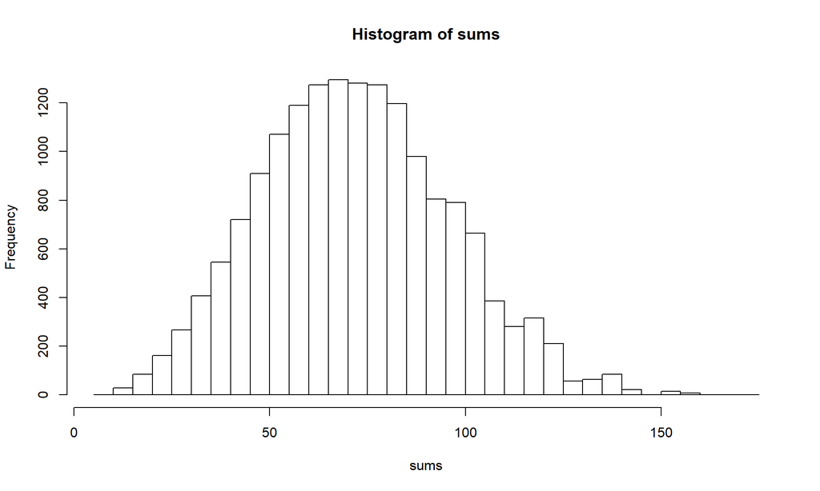

```r
hist(sums, breaks=50)
```

In this case, it is ‘somewhat’ normal… Assuming that it was, we then compute each coin’s expected value:

$$E = \frac{1}{4}\times ( 1c + 5c + 10c + 25c) = 10.25c$$
and variance:

$$\frac{1}{4}\times \Big( (1 - 10.25)^{2} + (5 - 10.25)^{2} + (10 - 10.25)^{2} + (25 - 10.25)^{2} \Big) = 82.68$$

Since we are dealing with a sum of 7 coins, expected value and variance add together

```r
exp.val  <- 7*10.25
variance <- 7*82.68
```

Now we need to find the total area larger than 100.

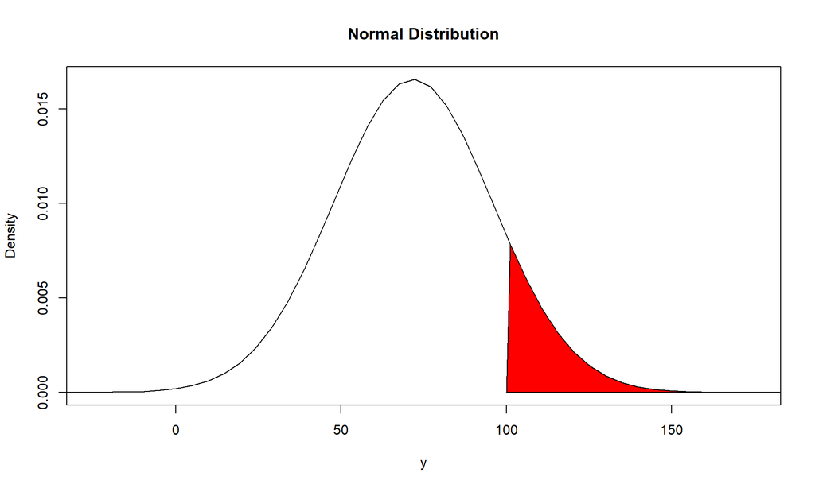

```r
1 - pnorm(100, mean, sd)
```

```
## [1] 0.1201428
```

This result is quite close to the real value of $12.8\%$.